# Praca domowa nr 3

Jakub Lange

2022-11-13

## Opis eksperymentu

Celem eksperymentu było sprawdzenie, czy ludzie potrafią szybko i skutecznie odczytywać dane z tzw. Radar Plotów. Dla porównania badani odczytywali również dane z najbardziej typowego wykresu - słupkowego. Eksperyment składał się z dwóch zadań. W każdym zadaniu należało spośród kilku zdań zaznaczyć te prawdziwe. Badani mierzyli czas rozwiązania obu zadań. Badanie przeprowadzono na dwa sposoby: część badanych odpowiadało za pomocą formularza stworzonego w Google Docs: https://forms.gle/hqKGSW5VMN3uPSbx8 a pozostali rozwiązywali taki sam test w wersji analogowej.

# Wykresy i pytania

Poniżej zamieszczono użyte w badaniu wykresy, pytania i odpowiedzi (P - prawda, F - fałsz)

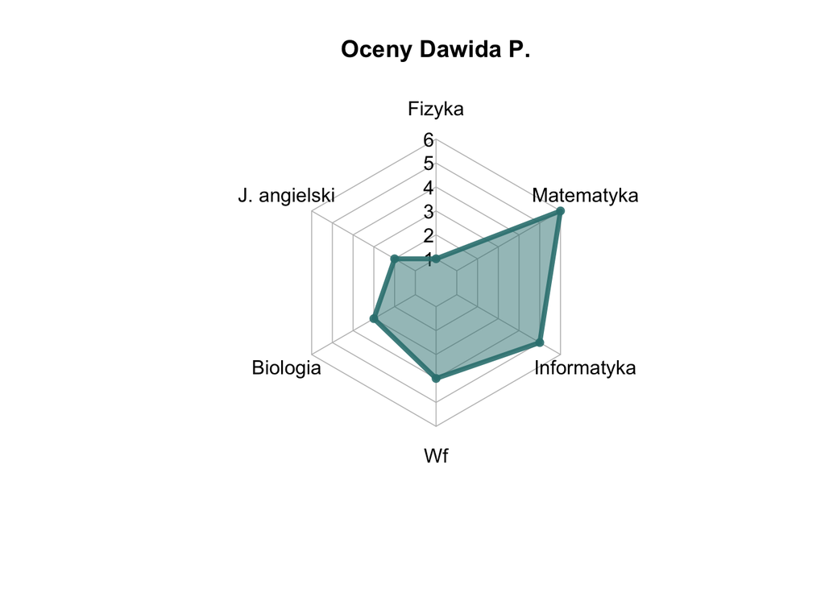

Zadanie 1: Zaznacz zdania prawdziwe:

1. Dawid nie zdał z fizyki (P)
2. Dawid zdał matematykę na ocenę 6 (P)
3. Dawid jest lepszy z biologii niż z angielskiego (P)
4. Zaznaczony na wykresie nieregularny kształt oznacza, że oceny Dawida są zróżnicowane (P)

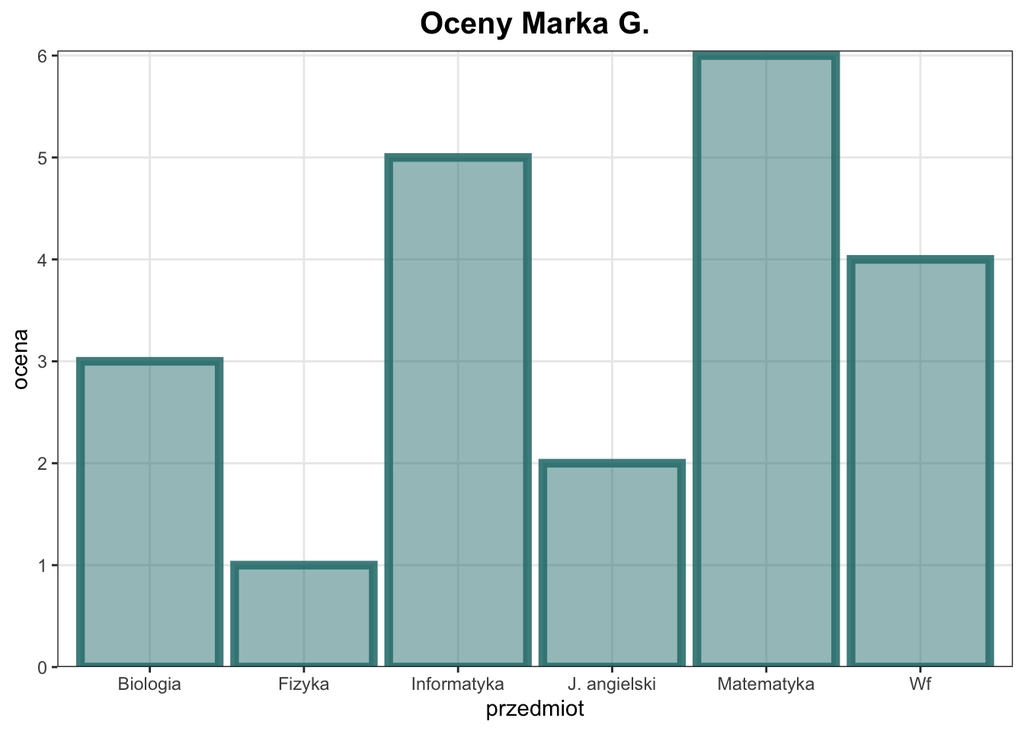

Zadanie 2: Zaznacz zdania prawdziwe

1. Marek zdał fizykę (F)
2. Marek jest lepszy z angielskiego niż z wf-u (F)
3. Słupki są różnej wysokości, co świadczy o zróżnicowaniu ocen Marka (P)
4. Marek zdał informatykę z oceną 5 (P)

## Wyniki

Grupa badawcza wyniosła 16 osób. Dużą część z nich stanowili studenci naszego wydziału, co mogło zaburzyć wynik eksperymentu (ponieważ prawdopodobnie są oni ponadprzeciętnie biegli w czytaniu wykresów).

Same pytania okazały się zbyt proste - wszystkie 16 osób uzyskały 100% poprawnych odpowiedzi. Podczas analizy wyników pozostało skupić się na czasie odpowiedzi na pytania.

Czas odpowiedzi w sekundach na zadane pytania

[output not shown]

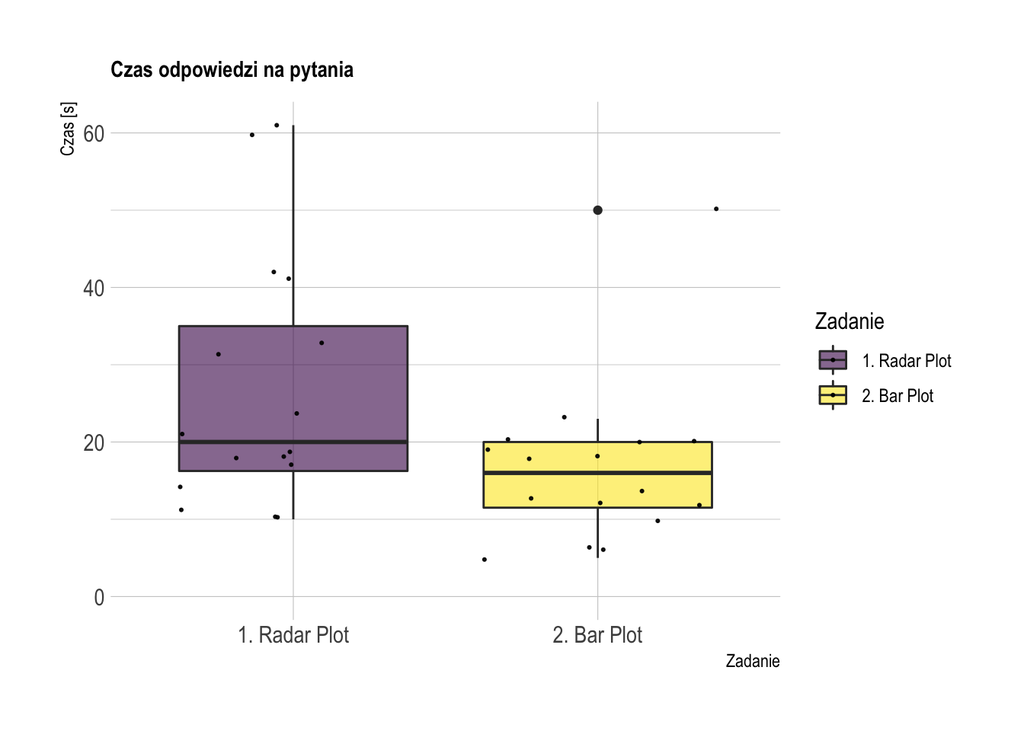

## Podsumowanie

Grupa badawcza w eksperymencie była stanowczo za mała, żeby na jego podstawie wyciągać daleko idące wnioski. Eksperyment był też obarczony dużą niedokładnością - osoby, które wypełniały formularz online, same mierzyły sobie czas i podawały go z małą dokładnością (przeważnie w sekundach). Mimo wszystko przypuszczenie, że RadarPloty cechują się mniejszą rozczytywalnością w społeczeństwie, wydaje się uzasadnione.